# 0619a

```python
import matplotlib.pyplot as plt
import numpy as np
import mpmath as mp
pi=mp.pi
e=mp.e
```

## 基本事項

・複素数 $z=x+iy$ ($x,y$は実数，$i^2=-1$)と表せる数

・複素数全体の集合を$\mathbb{C}$と書く

・$x$を実部という．$x=\mathrm{Re}(z)$と書く

・$y$を虚部という．$y=\mathrm{Im}(z)$と書く

・演算について 実数と同じように計算出来る（体を成す）

和　$(1+2i)+(5+3i)=6+5i$

積　$(1+2i)\times(5+3i)=(1\times5-2\times3)+(2\times5+1\times3)i=-1+13i$

・$z=re^{i\theta}$のように書く場合もある．（$r,\theta$は実数）$x=r\cos \theta,y=r\sin \theta$

・特に$e^{i\theta}=\cos\theta+i\sin\theta$

・$e^{i\pi}=\cos\pi+i\sin\pi=-1$

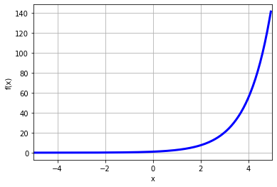

```python
mp.plot(mp.exp)
```

## 図の見方

・複素数$z=re^{i\theta}$に色を対応させることで図示できる．

・$r=0$で黒　$r=\infty$で白　$r$が大きくなるにつれて白っぽくなる

・$\theta=0$で赤　$\theta=\dfrac{2\pi}{3}$で緑　$\theta=\dfrac{4\pi}{3}$で青

のように定義する．

・実際にこれを実装することも可能だが面倒なのでmpmathライブラリを用いる．

## 基本の図

・$f(z)=z$を図示すると，下のようになる．

・$f(z)=0$となる点を**零点**という．（零点は黒！）

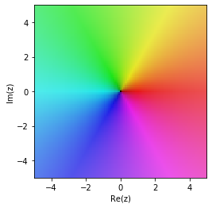

```python
mp.cplot(lambda z:z, [-5,5],[-5,5],points=10000)
```

・$f(z)=z^2$の図

・$z=re^{\theta i}$に対し$z^2=r^2e^{2\theta i}$

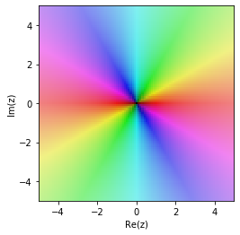

```python
mp.cplot(lambda z:z**2, [-5,5],[-5,5],points=10000)
```

・$f(z)=\dfrac{1}{z}$のグラフ

・原点で$|f(z)|=\infty$

・原点は**極**であるという．（極は白！）

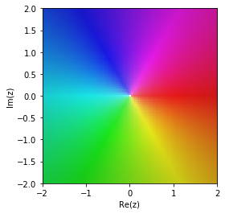

```python
mp.cplot(lambda z:1/(z+1e-10), [-2,2],[-2,2],points=10000)
```

・極とは少し違うヤバい点があることもある

・真性特異点（下の例では0への近づき方を変えると極限の値が違っている）

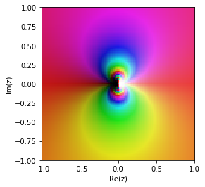

```python
mp.cplot(lambda z:mp.exp(1/z), [-1,1],[-1,1],points=10000)
```

## 指数関数

定義　$\exp(z)=e^z=1+z+\dfrac{z^2}{2!}+\dfrac{z^3}{3!}+\cdots$

・$\exp(z)=\exp(x+iy)=\exp(x)\exp(iy)=e^x(\cos y+i\sin y)$

・$\sin, \cos$が周期関数なので，$\exp(x+iy)=\exp(x+i(2\pi+y))$

・$y$が$2\pi$増えても値が同じ！

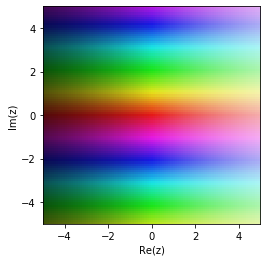

```python
mp.cplot(lambda z:mp.exp(z), [-5,5],[-5,5],points=10000)
```

## 対数関数

・通常の対数を$\log x$，複素数における対数を$\mathrm{Log}(z)$と書くことにする．

定義　$\mathrm{Log} (z)=w\iff z=\exp(w) $

・$z=re^{i\theta}$に対して，$\mathrm{Log}(z)= \log r+i\theta$と定義したいが...

・例えば$z=1=1\cdot\exp(0i)=1\cdot\exp((0+2\pi)i)$なので$\mathrm{Log}(z)=0=0+2\pi i$？？

・実は値がいくつもある多価関数になってしまう！

・これでは困るので対処法として，その中の1個を選ぶことにする（$\theta=\arg z\in(-\pi,\pi]$とする）．これを**主値**とよぶ

・主値を使って定義すると下のように不連続な部分がでてきてしまう．（$\mathrm{Log}(z)$は負の実数に対して微分できない）

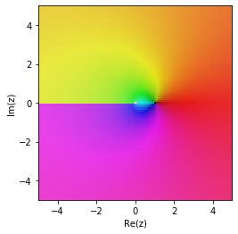

```python
mp.cplot(lambda z:mp.log(z), [-5,5],[-5,5],points=10000)
```

## 指数と対数の面白い性質

・定義から$\exp(\log(z))=z$

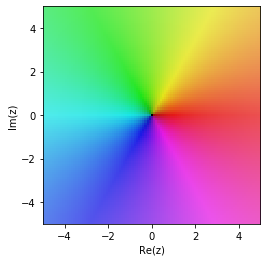

```python
mp.cplot(lambda z:mp.exp(mp.log(z)), [-5,5],[-5,5],points=10000)
```

・関数として，$\log(\exp(z))=z$ではない！

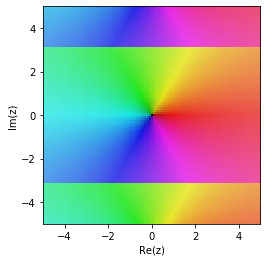

```python
mp.cplot(lambda z:mp.log(mp.exp(z)), [-5,5],[-5,5],points=10000)
```

## おまけ

・三角関数の図示　上から順に$\sin,\cos,\tan$

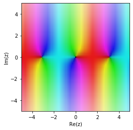

```python
mp.cplot(lambda z:mp.sin(z), [-5,5],[-5,5],points=10000)
```

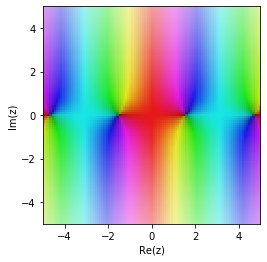

```python
mp.cplot(lambda z:mp.cos(z), [-5,5],[-5,5],points=10000)
```

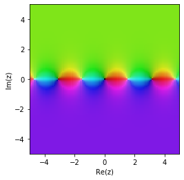

```python
mp.cplot(lambda z:mp.tan(z), [-5,5],[-5,5],points=10000)
```